# Revised Assignment4

June 23, 2018

## Contents

- Table Examination
- Columns Examination
  - Numerical Columns
- New Features
  - Comparing Standardized Total Payment
  - Standardized Difference Between Medical Coverage and Medical Payment
  - Number of Discharges

## Table

## Table Examination

| DRG_Def | Pro_Id | Pro_Name | Pro_Add | Pro_City | Pro_State | Pro_Zip | HRR | Tot_Discharges | Avg_Cov_Charges | Avg_Tot_Payments | Avg_Med_Payments | DRG_Num |
| --- | --- | --- | --- | --- | --- | --- | --- | --- | --- | --- | --- | --- |
| 001 - HEART TRANSPLANT OR IMPLANT OF HEART ASSIST SYSTEM W MCC | 10033 | UNIVERSITY OF ALABAMA HOSPITAL | 619 SOUTH 19TH STREET | BIRMINGHAM | AL | 35233 | AL - Birmingham | 11 | 1014783 | 171081.2 | 141193.9 | 001 |
| 001 - HEART TRANSPLANT OR IMPLANT OF HEART ASSIST SYSTEM W MCC | 30103 | MAYO CLINIC HOSPITAL | 5777 EAST MAYO BOULEVARD | PHOENIX | AZ | 85054 | AZ - Phoenix | 28 | 382051 | 194081.4 | 167512.0 | 001 |

## Columns

## Column Examination - Avg_Cov_Charges

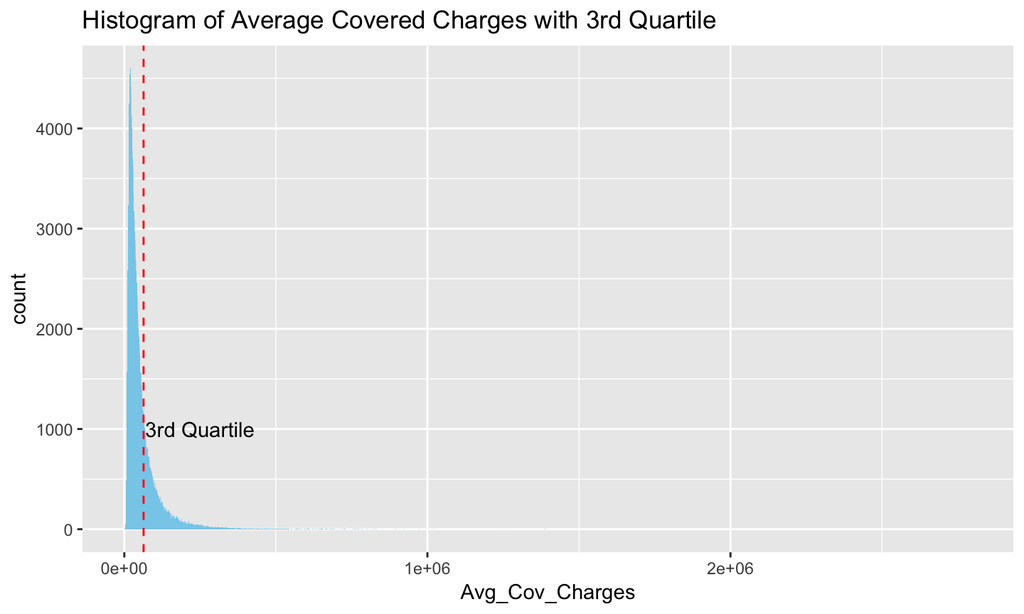

## Column Examination - Avg_Tot_Payments

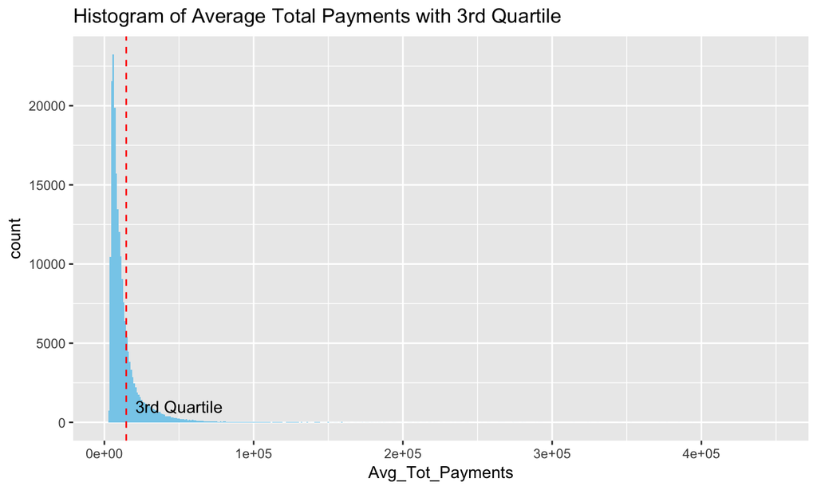

## Column Examination - Avg_Med_Payments

- As we can see from the three histograms, all the variables are highly right-skewed.

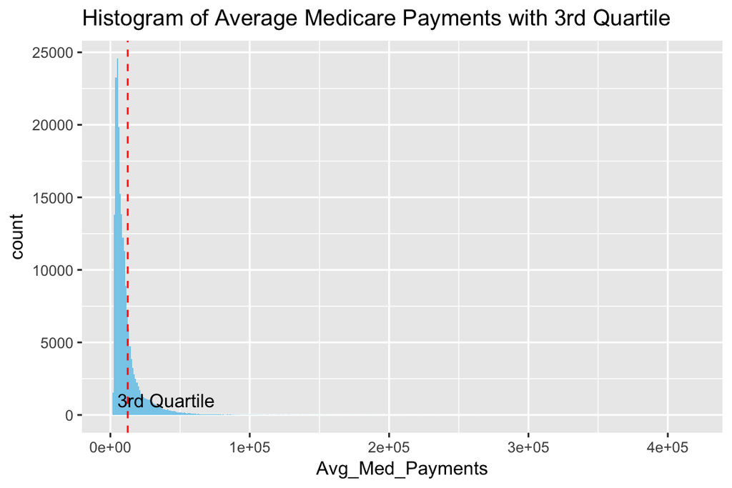

## New Features

## Introducing New Features

1. Comparing Standardized Total Payment  
2. Standardized Difference Between  
Medical Coverage and Medical Payment  
3. Standardized Number of Discharges

## Comparing Standardized Total Payment

## 1) Standardized Total Payment

Here, I divided the dataset into three groups:  
`1_to_945`, `946_to_1890`, and `1890_to_2837`

| DRG_Def | n_row_group | group_class |
| --- | --- | --- |
| 906 - HAND PROCEDURES FOR INJURIES | 1 | 1_to_945 |
| 915 - ALLERGIC REACTIONS W MCC | 1 | 1_to_945 |
| 927 - EXTENSIVE BURNS OR FULL THICKNESS BURNS W MV >96 HRS W SKIN GRAFT | 1 | 1_to_945 |
| 950 - AFTERCARE W/O CC/MCC | 1 | 1_to_945 |
| 951 - OTHER FACTORS INFLUENCING HEALTH STATUS | 1 | 1_to_945 |
| 989 - NON-EXTENSIVE O.R. PROC UNRELATED TO PRINCIPAL DIAGNOSIS W/O CC/MCC | 1 | 1_to_945 |

As we can see from the above table, there are certain drug definition groups that have only one entity(case).

## 1) Standardized Total Payment

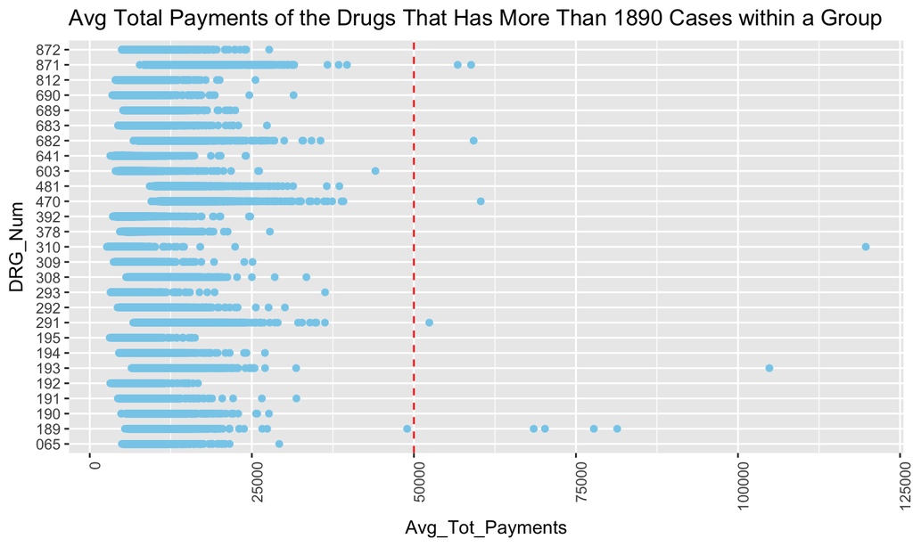

It looks like we see some outliers, though, we should not be so sure, since the price can also vary from states.

## 1) Standardized Total Payment

I generated three columns as follows:  
- `Mu_DRG_State_Total_Payment`: Mean of `Avg_Tot_Payments` grouped by drug group (`Drug_Num`) and state (`Prov_State`).  
- `Sd_DRG_State_Total_Payment`: Standard deviation of `Avg_Tot_Payments` grouped by drug group (`Drug_Num`) and state (`Prov_State`).  
- `Std_DRG_State_Total_Payment`: Standardized `Avg_Tot_Payments` using Z-score with `Mu_DRG_State_Total_Payment` and `Sd_DRG_State_Total_Payment`

## 1) Standardized Total Payment

| DRG_Num | Pro_State | Mu_DRG_State_Total_Payment | Sd_DRG_State_Total_Payment | Std_DRG_State_Total_Payment |
| --- | --- | --- | --- | --- |
| 310 | AL | 3563.514 | 483.674 | -0.1821150 |
| 310 | AL | 3563.514 | 483.674 | -0.2088065 |
| 310 | AL | 3563.514 | 483.674 | -0.7699902 |
| 310 | AL | 3563.514 | 483.674 | -0.5502762 |
| 310 | AL | 3563.514 | 483.674 | 0.4886880 |
| 310 | AL | 3563.514 | 483.674 | -0.9001192 |

After dividing into three group depending on the number of providers in drug_definition,  
I filtered only the second and third group, which basically have more than 946 providers in each drug definition group.

## 1) Standardized Total Payment

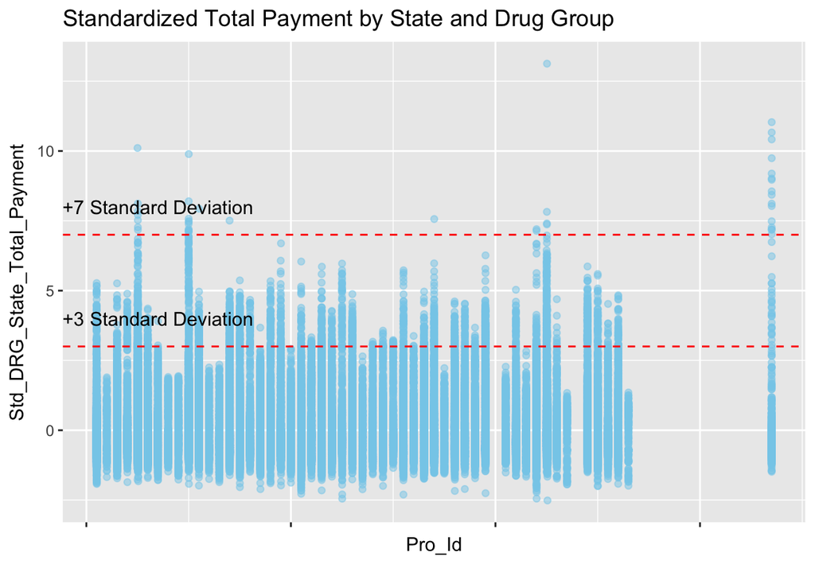

As we can see from the above graph, we can notice a few distinctively high standardized values.  
We might want to further exam those values.

## Standardized Difference Between Medical Coverage and Medical Payment

## 2) Difference Between Medical Coverage and Payment

\[Z=\frac{X-\mu }{\sigma }=\frac{DiffMedCovMedPay-MuDiff}{Sd_Diff}\]

## 2) Difference Between Medical Coverage and Payment

This table below shows the examples of how standardized difference looks like.

| DRG_Num | Diff_MedCov_MedPay | Mu_Diff | Sd_Diff | Standard_Diff |
| --- | --- | --- | --- | --- |
| 001 | 873589.5 | 741484.5 | 441045.3 | 0.2995271 |
| 001 | 214539.0 | 741484.5 | 441045.3 | -1.1947648 |
| 001 | 677461.9 | 741484.5 | 441045.3 | -0.1451611 |
| 001 | 1284324.8 | 741484.5 | 441045.3 | 1.2308038 |
| 001 | 1131869.1 | 741484.5 | 441045.3 | 0.8851347 |
| 001 | 1046181.8 | 741484.5 | 441045.3 | 0.6908526 |

## 2) Difference Between Medical Coverage and Payment

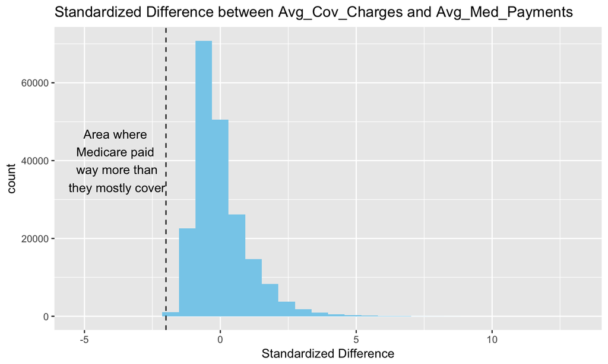

## 2) Difference Between Medical Coverage and Payment

As such, I looked at the providers with the standardized difference even less than -2.

| DRG_Num | Pro_Id | Avg_Cov_Charges | Avg_Med_Payments | Standard_Diff |
| --- | --- | --- | --- | --- |
| 060 | 190098 | 8031.73 | 7872.80 | -2.294081 |
| 191 | 50373 | 16165.18 | 25440.91 | -2.015600 |
| 227 | 330204 | 27817.91 | 62671.73 | -2.064512 |
| 228 | 240010 | 121708.14 | 62987.19 | -2.080739 |
| 247 | 330128 | 23774.83 | 25166.06 | -2.071884 |
| 247 | 330204 | 26902.86 | 26728.09 | -2.026768 |
| 652 | 210002 | 92689.72 | 79761.80 | -2.051449 |
| 652 | 210009 | 144982.28 | 128110.99 | -2.009393 |
| 743 | 190128 | 21031.00 | 36138.74 | -2.283680 |
| 743 | 450674 | 41911.45 | 66521.18 | -2.759642 |
| 775 | 190128 | 9914.00 | 40970.00 | -4.834590 |
| 781 | 450674 | 45574.87 | 83661.93 | -2.786989 |
| 894 | 50543 | 10716.86 | 28666.59 | -3.041616 |
| 894 | 230275 | 1715.00 | 19729.37 | -3.050006 |
| 897 | 50543 | 11885.44 | 29827.84 | -2.350421 |
| 897 | 230275 | 4087.22 | 21698.11 | -2.328666 |
| 897 | 390025 | 5699.35 | 24106.39 | -2.380912 |

## Standardized Number of Discharges

## 3) Number of Discharges

- First, I made `Mean_Discharge` and `Stdv_Discharges` to eventually create `Standardized_Discharges` column.  
- `Standardized_Discharges`: The standardized value of the number of discharges, grouped by drug and state.

| DRG_Num | Pro_Id | Tot_Discharges | Standardized_Discharges |
| --- | --- | --- | --- |
| 987 | 240057 | 11 | -0.7395442 |
| 987 | 250078 | 12 | -0.7071068 |
| 987 | 250102 | 20 | 0.7071068 |
| 987 | 260032 | 26 | 1.1338934 |
| 987 | 260096 | 11 | -0.7559289 |
| 987 | 260108 | 14 | -0.3779645 |

## 3) Number of Discharges

Next, I looked at the histogram of the standardized number of discharges.  
We can see that they are right-skewed.

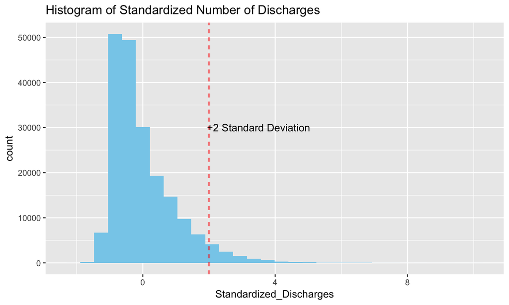

## 3) Number of Discharges

Finally, I combined the standardized number of discharges and the standardized difference. (`Standardized_Discharges` and`Standard_Diff`) and plotted as follows.

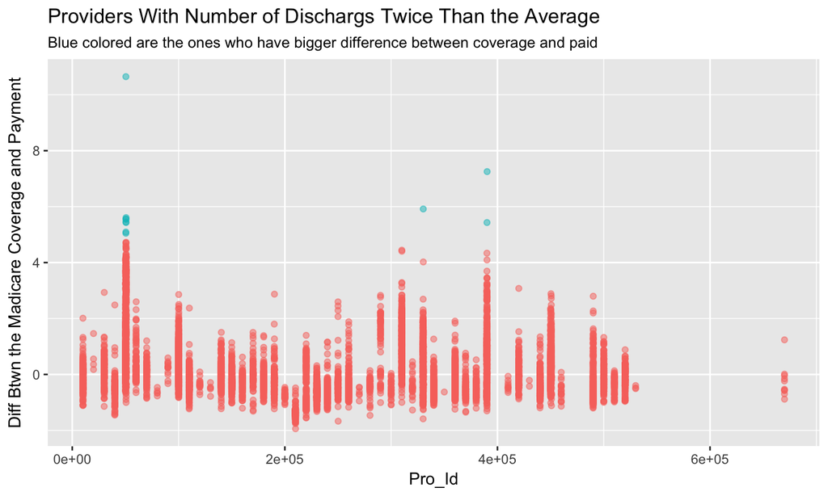

## 3) Number of Discharges

- Since those \(11\) cases are where the difference between Medicare coverage and Medicare payment is huge, and where more discharges happened as well, we might want to further examine those anomalies.

| DRG_Num | Pro_Id | Standardized_Discharges | Standard_Diff |
| --- | --- | --- | --- |
| 003 | 50625 | 2.602768 | 5.430464 |
| 074 | 390290 | 5.601616 | 7.252538 |
| 101 | 330214 | 5.573949 | 5.916512 |
| 177 | 390164 | 2.392107 | 5.430926 |
| 206 | 50441 | 2.413592 | 10.647811 |
| 246 | 50625 | 6.548840 | 5.548275 |
| 247 | 50625 | 4.186539 | 5.608008 |
| 292 | 50441 | 2.198379 | 5.558162 |
| 315 | 50441 | 3.027563 | 5.092814 |
| 326 | 50441 | 2.179774 | 5.046248 |
| 948 | 50441 | 2.142012 | 5.449465 |